# Tidy Tuesday

Week 35

Author

Cristian T

Published

September 3, 2024

This week we are exploring the Power Rangers Franchise!

In 1993, five ordinary teenagers exploded on the pop-culture scene with the launch of Mighty Morphin Power Rangers. Together they broke down barriers. They defeated evil by demonstrating teamwork, inclusivity, and diversity to people of all ages. Today, this grand tradition continues as new Ranger teams and new generations of fans discover these essential values again.

The series, created by Haim Saban, has one of the most popular taglines in history, “It’s Morphin Time!” The TV series “Mighty Morphin Power Rangers” (MMPR) launched on August 28, 1993. Power Rangers quickly became the #1 kids action brand and a global phenomenon. With its current 25th season, “Power Rangers Super Ninja Steel,” the show is now the second-longest-running, non-soap-opera, scripted program on American TV (after “The Simpsons”). There are also over 830 episodes in its library. Currently, Power Rangers is seen in more than 150 markets around the world. It’s also translated into numerous languages and is a favorite on many indispensable children’s programming blocks around the world. Go Go Power Rangers on 8.28!

power_rangers_episodes.csv

| variable | class | description |
| --- | --- | --- |
| season_title | character | title of the overall season |
| episode_num | double | number of this episode within this season |
| episode_title | character | title of this episode |
| air_date | double | date on which this episode first aired in the U.S. |
| IMDB_rating | double | average rating among IMDB users |
| total_votes | double | total votes on IMDB |
| desc | character | free-text description of this episode |

power_rangers_seasons.csv

| variable | class | description |
| --- | --- | --- |
| season_title | character | title of this season |
| season_num | double | season number |
| number_of_episodes | double | number of episodes in this season |
| air_date_first_ep | double | date on which the first episode in this season first aired in the U.S. |
| air_date_last_ep | character | date on which the last episode in this season first aired in the U.S. |
| producer | character | the company that produced this season |
| IMDB_rating | double | average rating of this seasons among IMDB users |

```r
# Load the tidytuesday package
suppressMessages(library(tidytuesdayR)) # For accessing TidyTuesday datasets
suppressMessages(library(skimr)) # For summary and descriptive statistics
suppressMessages(library(tidyverse)) # For data manipulation and visualization
suppressMessages(library(dplyr)) # For data manipulation and transformation
suppressMessages(library(ggplot2)) # For data visualization
suppressMessages(library(RColorBrewer)) # For color palettes in visualizations
suppressMessages(library(mdsr)) # For spatial analysis
suppressMessages(library(tidytext)) # For text mining and analysis
suppressMessages(library(textstem)) # For lemmatization


# Load the current week's dataset
tuesdata <- tidytuesdayR::tt_load('2024-08-27')
power_rangers_episodes <- tuesdata$power_rangers_episodes
pwe <- power_rangers_episodes
power_rangers_seasons <- tuesdata$power_rangers_seasons
pws <- power_rangers_seasons


# Explore the structure of the dataset
str(pwe)
```

```
spc_tbl_ [921 × 7] (S3: spec_tbl_df/tbl_df/tbl/data.frame)
 $ season_title : chr [1:921] "Mighty Morphin (Season 1)" "Mighty Morphin (Season 1)" "Mighty Morphin (Season 1)" "Mighty Morphin (Season 1)" ...
 $ episode_num  : num [1:921] 0 1 2 3 4 5 6 7 8 9 ...
 $ episode_title: chr [1:921] "The Lost Episode" "Day of the Dumpster" "High Five" "Teamwork" ...
 $ air_date     : Date[1:921], format: "1999-05-22" "1993-08-28" ...
 $ IMDB_rating  : num [1:921] 6.7 7.4 6.9 7.3 6.9 6.6 7.3 6.4 7 6 ...
 $ total_votes  : num [1:921] 113 687 564 546 535 516 531 510 504 494 ...
 $ desc         : chr [1:921] "Original version of the premiere episode." "Following the accidental release of long-imprisoned evil space-sorceress Rita Repulsa, a benevolent sage known "| __truncated__ "Rita plans to trap the Rangers in a time trap like the one she trapped Zordon in and to do this …
 - attr(*, "spec")=
  .. cols(
  ..   season_title = col_character(),
  ..   episode_num = col_double(),
  ..   episode_title = col_character(),
  ..   air_date = col_date(format = ""),
  ..   IMDB_rating = col_double(),
  ..   total_votes = col_double(),
  ..   desc = col_character()
  .. )
 - attr(*, "problems")=<externalptr>
```

```r
skim(pws)
```

**Variable type: numeric**

| var | n | na | mean | sd | p0 | p25 | p50 | p75 | p100 |
| --- | --- | --- | --- | --- | --- | --- | --- | --- | --- |
| season_num | 28 | 0 | 14.50 | 8.23 | 1.0 | 7.75 | 14.5 | 21.25 | 28.0 |
| number_of_episodes | 28 | 0 | 34.00 | 11.13 | 20.0 | 22.00 | 32.5 | 40.75 | 60.0 |
| IMDB_rating | 28 | 0 | 6.36 | 0.56 | 5.1 | 6.00 | 6.5 | 6.73 | 7.3 |

```r
str(pws)
```

```
spc_tbl_ [28 × 7] (S3: spec_tbl_df/tbl_df/tbl/data.frame)
 $ season_title      : chr [1:28] "Mighty Morphin (Season 1)" "Mighty Morphin (Season 2)" "Mighty Morphin (Season 3)" "Zeo" ...
 $ season_num        : num [1:28] 1 2 3 4 5 6 7 8 9 10 ...
 $ number_of_episodes: num [1:28] 60 52 33 50 45 43 45 40 40 40 ...
 $ air_date_first_ep : Date[1:28], format: "1993-08-28" "1994-07-21" ...
 $ air_date_last_ep  : chr [1:28] "1994-05-23" "1995-05-20" "1995-11-27" "1996-11-27" ...
 $ producer          : chr [1:28] "Saban" "Saban" "Saban" "Saban" ...
 $ IMDB_rating       : num [1:28] 6.5 6.5 6.5 6.6 5.7 7.3 6.9 6.5 7.1 6.3 ...
 - attr(*, "spec")=
  .. cols(
  ..   season_title = col_character(),
  ..   season_num = col_double(),
  ..   number_of_episodes = col_double(),
  ..   air_date_first_ep = col_date(format = ""),
  ..   air_date_last_ep = col_character(),
  ..   producer = col_character(),
  ..   IMDB_rating = col_double()
  .. )
 - attr(*, "problems")=<externalptr>
```

```r
skim(pws)
```

**Variable type: numeric**

| var | n | na | mean | sd | p0 | p25 | p50 | p75 | p100 |
| --- | --- | --- | --- | --- | --- | --- | --- | --- | --- |
| season_num | 28 | 0 | 14.50 | 8.23 | 1.0 | 7.75 | 14.5 | 21.25 | 28.0 |
| number_of_episodes | 28 | 0 | 34.00 | 11.13 | 20.0 | 22.00 | 32.5 | 40.75 | 60.0 |
| IMDB_rating | 28 | 0 | 6.36 | 0.56 | 5.1 | 6.00 | 6.5 | 6.73 | 7.3 |

```r
# View the first few rows of the dataset
head(pwe)
```

| season_title | episode_num | episode_title | air_date | IMDB_rating | total_votes | desc |
| --- | --- | --- | --- | --- | --- | --- |
| Mighty Morphin (Season 1) | 0 | The Lost Episode | 1999-05-22 | 6.7 | 113 | Original version of the premiere episode. |
| Mighty Morphin (Season 1) | 1 | Day of the Dumpster | 1993-08-28 | 7.4 | 687 | Following the accidental release of long-imprisoned evil space-sorceress Rita Repulsa, a benevolent sage known as Zordon drafts a group of five teenagers to help protect the planet as Dino-powered war… |
| Mighty Morphin (Season 1) | 2 | High Five | 1993-09-04 | 6.9 | 564 | Rita plans to trap the Rangers in a time trap like the one she trapped Zordon in and to do this she sends a fresh monster to the amusement park. Will the Power Rangers be able to defeat Bones, and wil… |
| Mighty Morphin (Season 1) | 3 | Teamwork | 1993-09-08 | 7.3 | 546 | Trini and Kimberly set up a petition to clean up pollution and there are plenty of people willing to sign but no one to help speak up against it, not even the other rangers. Rita seizes the opportunit… |
| Mighty Morphin (Season 1) | 4 | A Pressing Engagement | 1993-09-09 | 6.9 | 535 | Jason is trying to break the bench press record set by Bulk, but he keeps getting distracted and is unable to beat the record. First, his coach, the Juice Bar's owner Ernie, loses count. Then Kimberly… |
| Mighty Morphin (Season 1) | 5 | Different Drum | 1993-09-10 | 6.6 | 516 | Kimberly's deaf friend feels out of place in dance class because she has trouble following the movements since she can't hear the instructions or the music to follow along. Some of the girls in the da… |

```r
head(pws)
```

| season_title | season_num | number_of_episodes | air_date_first_ep | air_date_last_ep | producer | IMDB_rating |
| --- | --- | --- | --- | --- | --- | --- |
| Mighty Morphin (Season 1) | 1 | 60 | 1993-08-28 | 1994-05-23 | Saban | 6.5 |
| Mighty Morphin (Season 2) | 2 | 52 | 1994-07-21 | 1995-05-20 | Saban | 6.5 |
| Mighty Morphin (Season 3) | 3 | 33 | 1995-09-02 | 1995-11-27 | Saban | 6.5 |
| Zeo | 4 | 50 | 1996-04-20 | 1996-11-27 | Saban | 6.6 |
| Turbo | 5 | 45 | 1997-04-19 | 1997-11-24 | Saban | 5.7 |
| In Space | 6 | 43 | 1998-02-06 | 1998-11-21 | Saban | 7.3 |

```r
# Join the datasets on the common key (e.g., season_id)
combined_data <- pwe %>%
  inner_join(pws, by = "season_title")

combined_data %>% select("season_title", "season_num")
```

| season_title | season_num |
| --- | --- |
| Mighty Morphin (Season 1) | 1 |
| Mighty Morphin (Season 1) | 1 |
| Mighty Morphin (Season 1) | 1 |
| Mighty Morphin (Season 1) | 1 |
| Mighty Morphin (Season 1) | 1 |
| Mighty Morphin (Season 1) | 1 |
| Mighty Morphin (Season 1) | 1 |
| Mighty Morphin (Season 1) | 1 |
| Mighty Morphin (Season 1) | 1 |
| Mighty Morphin (Season 1) | 1 |

[output cut: 911 more lines]

```r
#tidytuesdayR::use_tidytemplate()
```

##### Clean the data

```r
# Doesn't appear the data needs cleaned
```

#### Missing Values

DF doesn’t have any missing data and column seem appropriate for what we are looking at

#### Plot 1 Top Words

```r
# Convert text to lowercase
pwe$desc <- tolower(pwe$desc)

# Count the words excluding stopwords
pwe_text_analysis <- pwe %>%
  unnest_tokens(word, desc) %>%
  anti_join(stop_words, by = "word") %>%
  count(word, sort = TRUE)

# Print Tidy Text
pwe_text_analysis
```

| word | n |
| --- | --- |
| rangers | 720 |
| power | 182 |
| ranger | 161 |
| monster | 158 |
| battle | 86 |
| time | 82 |
| tommy | 79 |
| earth | 78 |
| team | 75 |
| evil | 74 |

[output cut: 4488 more lines]

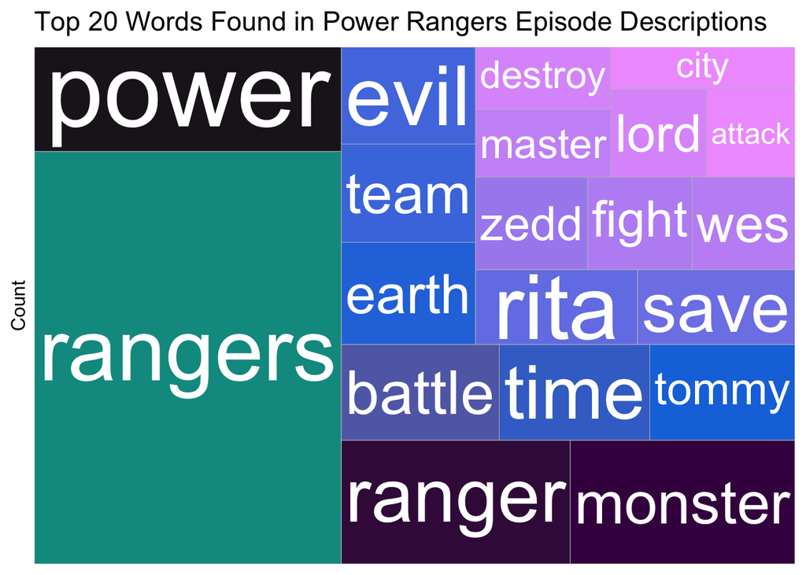

```r
# Get the top 20 words
top_20_words <- pwe_text_analysis %>%
  top_n(20, n)

suppressMessages(library(treemapify))

# Graph the top 20 words
ggplot(top_20_words, aes(area = n, fill = n, label = word)) +
    geom_treemap() +
    geom_treemap_text(color = "white", place = "centre", grow = TRUE) +
    scale_fill_gradientn(colors = pals::alphabet(20)) +
  labs(title = "Top 20 Words Found in Power Rangers Episode Descriptions",
       x = NULL,
       y = "Count") +
  theme_minimal(base_size = 14) +  # Set base font size for readability
  theme(axis.text.y = element_text(size = 8),
        axis.text.x = element_text(size = 10),
        axis.title.x = element_text(size = 12),
        axis.title.y = element_text(size = 12),
        panel.grid.major = element_blank(),
        panel.grid.minor = element_blank(),
        legend.position = "none") +
  scale_y_continuous(labels = NULL)
```

#### Plot 2 Bigram

A “bigram” is a pair of consecutive words that appear together in a text. It is a fundamental concept in n-gram analysis, where “n” represents the number of words in the sequence. By generating and analyzing bigrams from the top words data frame, we can uncover the relationships between key terms within the text. Visualizing these bigrams as a network graph allows us to see how words are connected, revealing prominent themes and recurring concepts within the episodes.

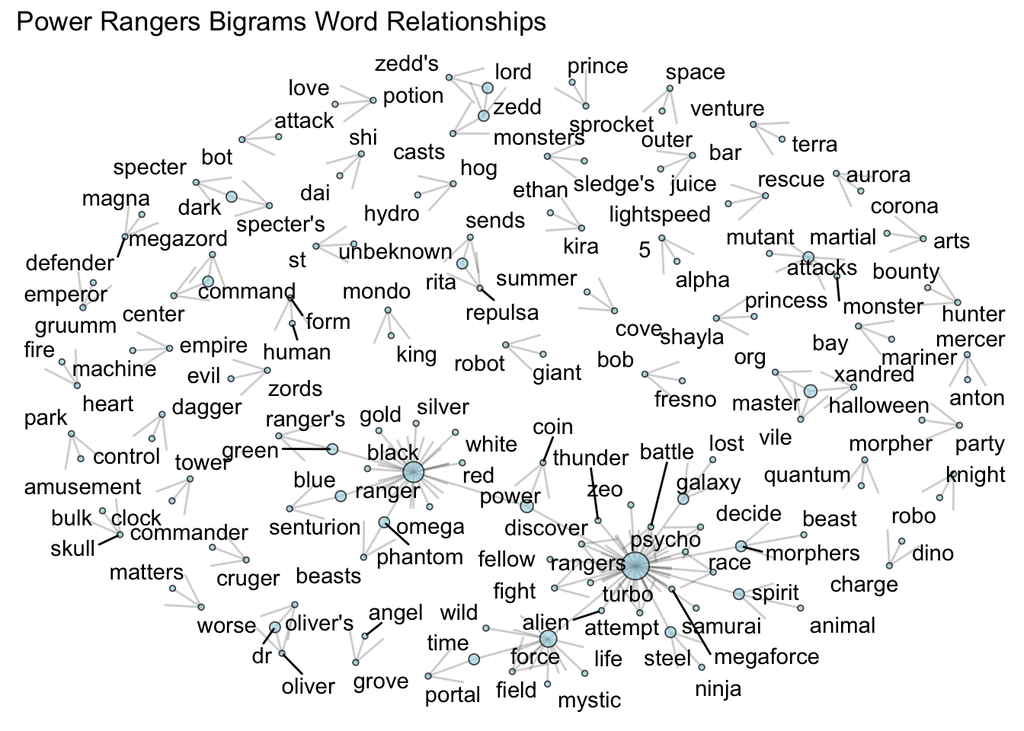

```r
suppressMessages(library(textdata))
suppressMessages(library(igraph))
suppressMessages(library(ggraph))
suppressMessages(library(tidygraph))

# Generates bigrams from the episode descriptions and counts their occurrences
pwe_bigrams <- pwe %>%
  unnest_tokens(bigram, desc, token = "ngrams", n = 2) %>%
  count(bigram, sort = TRUE)

# Separates each bigram into individual words for further processing
bigrams_separated <- pwe_bigrams %>%
  separate(bigram, c("word1", "word2"), sep = " ")

# Removes stop words
bigrams_filtered <- bigrams_separated %>%
  filter(!word1 %in% stop_words$word) %>%
  filter(!word2 %in% stop_words$word)

# Prepare the top_words data
top_words <- bigrams_filtered %>%
  arrange(desc(n)) %>%
  slice_head(n = 100)

# Create nodes data frame (unique words from bigrams)
nodes <- top_words %>%
  select(word1, word2) %>%
  pivot_longer(cols = everything(), names_to = "type", values_to = "name") %>%
  distinct(name) %>%
  mutate(id = row_number())

# Defines the edges (relationships) between words on bigram frequencies.
edges <- top_words %>%
  inner_join(nodes, by = c("word1" = "name")) %>%
  rename(from = id) %>%
  inner_join(nodes, by = c("word2" = "name")) %>%
  rename(to = id) %>%
  select(from, to, n)

# We created a network graph of the word relationships. The nodes data frame is made to list all unique words from the bigrams; each is assigned a unique identifier by pivoting the top_words data frame, ensuring that each word appears only once. The edges data frame is created to define the relationships between these words. It maps each word pair (from the bigrams) to their respective identifiers. It includes the frequency of each bigram as an edge attribute. These data frames are used to build a graph object.

# Create tbl_graph
graph <- tbl_graph(nodes = nodes, edges = edges, directed = TRUE)

# The tbl_graph() function creates a graph using the nodes and edges data frames.

# The layout for the graph is set to "fr" (Fruchterman-Reingold) arranges the nodes in a visually appealing manner. Edges are shown with arrows to indicate direction and nodes are displayed as points.

# Add Degree to Node Data to use node attributes (like degree) to control aspects of the visualization
V(graph)$degree <- degree(graph)

ggraph(graph, layout = "fr") +
  geom_edge_link(arrow = arrow(type = "open"), alpha = 0.2) +
    geom_node_point(aes(size = degree), shape = 21, fill = "lightblue", color = "black", alpha = 0.7) +
  geom_node_text(aes(label = name), repel = TRUE, max.overlaps = Inf) +
  theme(panel.background = element_rect(fill = "transparent"),
        legend.position = "none") +
  labs(title = "Power Rangers Bigrams Word Relationships")
```

```r
#save copy of image
#ggsave("Power Rangers Bigrams Word Relationships.png", plot = p, width = 8, height = 5, units = "in")
```

In the network graph, nodes represent unique words, and edges (lines connecting nodes) indicate the frequency with which word pairs co-occur. This visualization highlights the most influential words and their relationships, providing a clear view of the text’s structure. For example, high-frequency bigrams such as “power rangers” and “lord zedd” are central to understanding the core elements and recurring themes in the series. These terms highlight key characters and locations, such as “lord zedd” and “angel grove,” which play significant roles.

The graph also shows relationships and character pairings like “bulk skull” (Bulk and Skull) and “dr oliver”, indicating notable recurring characters. Additionally, lower-frequency bigrams such as “love potion” and “halloween party” may refer to specific plot points or events that, while less central, still contribute to the series’ narrative.

#### Plot 3 NRC

The NRC Emotion Lexicon is a powerful tool designed to analyze and categorize the emotional content of text. It associates words with eight basic emotions—anger, fear, anticipation, trust, surprise, sadness, joy, and disgust—and two overarching sentiments: positive and negative. This lexicon helps us understand the emotional underpinnings of various texts by mapping the words to specific emotional and sentiment categories.

When applied to TV show descriptions, such as those for “Power Rangers,” the NRC Emotion Lexicon provides insights into the emotional landscape of the content. By examining the frequency and distribution of different emotions, we can uncover how various feelings are portrayed and how they contribute to the overall narrative.

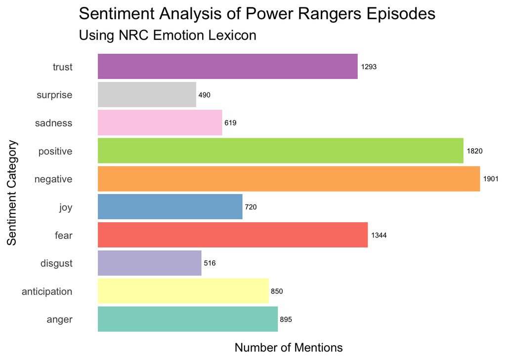

```r
# Download NRC lexicon
nrc_lexicon <- get_sentiments("nrc")

# Unnest tokens to get individual words
pwe_words <- pwe %>%
  unnest_tokens(word, desc)

# Join with NRC lexicon to get sentiment scores
pwe_sentiments <- pwe_words %>%
  inner_join(nrc_lexicon, by = "word")

# Count the sentiment scores
sentiment_counts <- pwe_sentiments %>%
  count(sentiment)

# Plot the sentiment counts
ggplot(sentiment_counts, aes(x = sentiment, y = n, fill = sentiment)) +
  geom_bar(stat = "identity") +  # Create the bar plot
  geom_text(aes(label = n), hjust = -0.2, size = 2.5) +  # Add totals at the end of the bars
  scale_fill_manual(values = brewer.pal(10, name = "Set3")) +  # Use color-blind-friendly palette
  coord_flip()  +  # Flip coordinates
  labs(
    title = "Sentiment Analysis of Power Rangers Episodes",
    subtitle = "Using NRC Emotion Lexicon",
    x = "Sentiment Category",
    y = "Number of Mentions",
  ) +
  theme_minimal(base_size = 14) +  # Set base font size for readability
  theme(axis.text.y = element_text(size = 10),
        axis.text.x = element_text(size = 10),
        axis.title.x = element_text(size = 12),
        axis.title.y = element_text(size = 12),
        panel.grid.major = element_blank(),
        panel.grid.minor = element_blank(),
        legend.position = "none") +
  scale_y_continuous(labels = NULL)
```

The “negative” sentiment category has the highest count (1,901), closely followed by “positive” (1,820). Despite a higher count of “negative” mentions, the “positive” sentiment is nearly as frequent (1,820 vs. 1,901), indicating that while the show deals with conflicts, it balances this with uplifting or positive moments. This balance could reflect the moral lessons or inspirational themes typical in children’s programming, where good triumphs over evil. However, specific negative emotions such as “fear” (1,344) and “anger” (895) are also prevalent, suggesting that the Mighty Morphin Power Rangers frequently deals with challenging situations, conflicts, or threats, which might contribute to the suspense and tension while also experiencing elements of danger or threat, likely due to the show’s premise involving battles against villains and monsters that is typical of an action-adventure series. We also see that “Disgust” (516) and “sadness” (619) also appear, indicating that the series occasionally explores themes of loss, disappointment, or moral disdain.

#### Plot 4 LDA with lemmatize

Latent Dirichlet Allocation (LDA) is a statistical model for topic modeling. We attempt to identify topics that occur in a collection of documents. We are treating each document as a season to see if anything stands out. LDA uses a beta measurment that shows the weight (probability) of each term within a particular topic. The beta value represents how strongly a term is associated with the topic. A higher value indicates that the term is more important or prevalent within that topic.

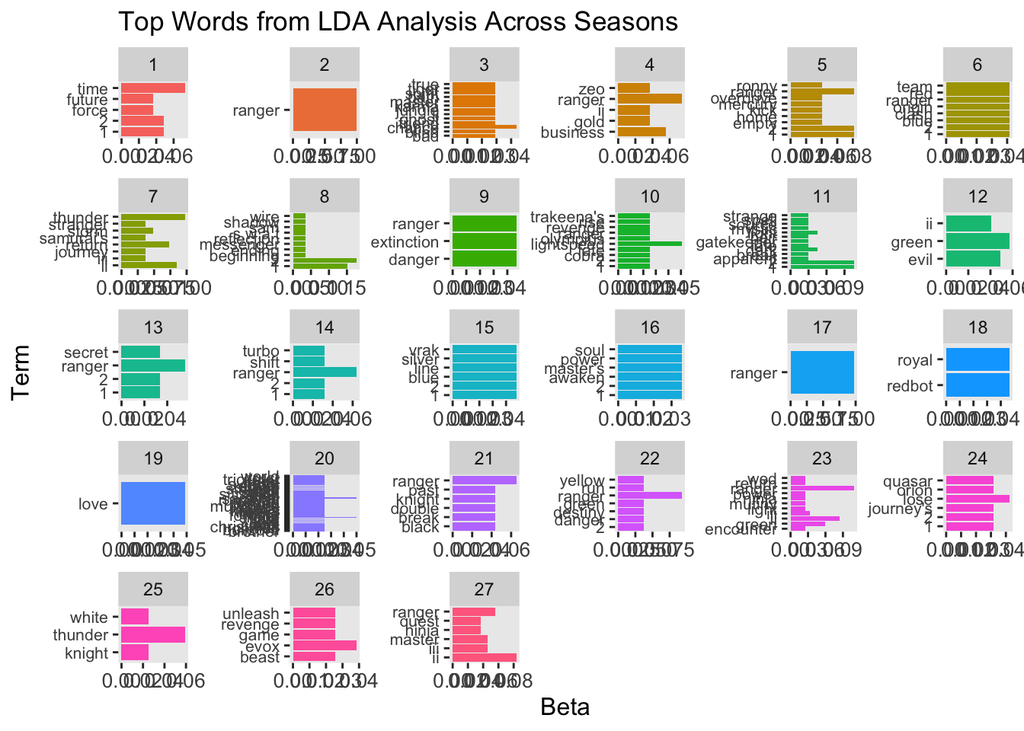

```r
suppressMessages(library(topicmodels)) # For topic modeling analysis
# Combine episode title by season
season_title <- combined_data %>%
  group_by(season_num) %>%
  summarize(episode_title = paste(episode_title, collapse = " "))

# Unnest tokens to get individual words and remove stop words
season_clean <- season_title %>%
  unnest_tokens(word, episode_title) %>%
  anti_join(stop_words, by = "word")

# Lemmatize the words to their base form
season_clean$word <- lemmatize_words(season_clean$word)

# Create a document-term matrix grouped by season
# Convert the count into a Document-Term Matrix (DTM), where rows represent documents (seasons), columns represent terms (words), and the matrix cells contain the count of words in each season.
season_dtm <- season_clean %>%
  count(season_num, word) %>%
  cast_dtm(season_num, word, n)

# Fit the LDA model
lda_model <- LDA(season_dtm, k = 27, control = list(seed = 1842))

# Extract the top terms in each topic
lda_topics <- tidy(lda_model, matrix = "beta")

# Get the top terms for each topic
# Beta is the term-topic matrix and represents the probability of each word belonging to each topic (season). Think of it as a measure of how important or relevant each word is to a particular topic (season). A higher value indicates that the term is more important or prevalent within that topic (season).
# We are filtering on a beta value to limit the amount of topics displayed
top_terms <- lda_topics %>%
  group_by(topic) %>%
  top_n(5, beta) %>%
  ungroup() %>%
  filter(beta >= 0.0245) %>%
  arrange(topic, -beta)

# Plot the top terms in each topic
ggplot(top_terms, aes(term, beta, fill = factor(topic))) +
  geom_col(show.legend = FALSE) +
  facet_wrap(~ topic, scales = "free") +
  scale_color_gradientn(colors = brewer.pal(25, "Set3")) +  # Use a color gradient
  coord_flip() +
  labs(title = "Top Words from LDA Analysis Across Seasons",
       x = "Term",
       y = "Beta") +
 theme(axis.text.y = element_text(size = 8),
        axis.text.x = element_text(size = 10),
        axis.title.x = element_text(size = 12),
        axis.title.y = element_text(size = 12),
        panel.grid.major = element_blank(),
        panel.grid.minor = element_blank())
```